# Macaque project data analysis

[output not shown]

#### Get data

```r
data <-read.csv("C:/Users/ag-bahl/Desktop/macaque_data/table_day_all.csv")
```

#### Plot of the basic relationship between the total time spent looking up and the number of seeds consumed during the observation period.

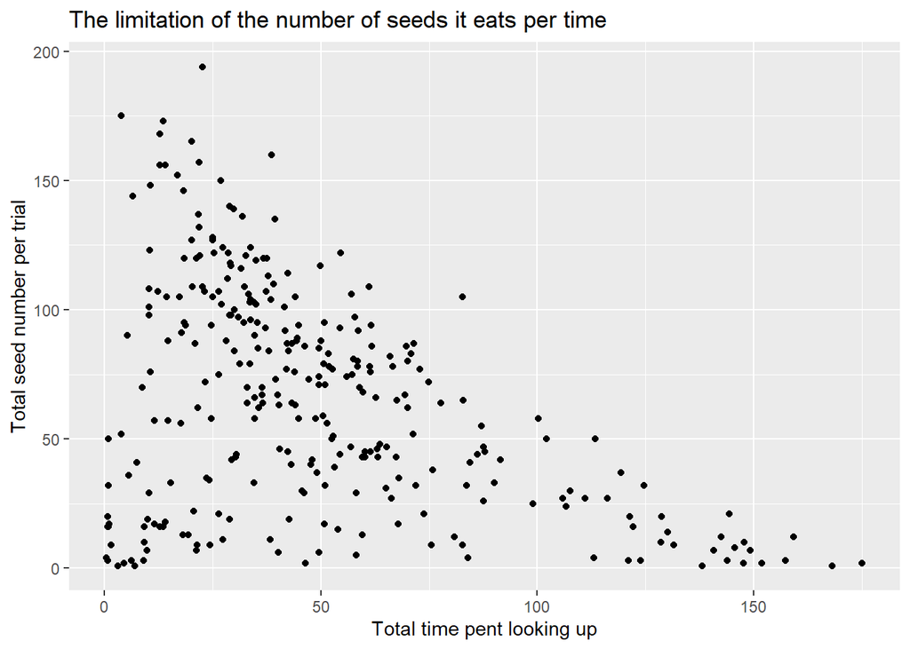

```r
ggplot(data, aes(x = up_tot_time, y= X.seed_nr)) +
  geom_point()+
  ggtitle('The limitation of the number of seeds it eats per time')+
  xlab('Total time pent looking up')+
  ylab('Total seed number per trial')
```

#### 1.Relationship between seed number and the presence/absence of external events, with trial length as an offset parameter.

X.seed_nr ~ externalyesno_chr + offset(log(trial_length))

```r
model1.1 <-brm(X.seed_nr ~ externalyesno_chr + offset(log(trial_length)),
               family = poisson,
               data = data,
               chain = 2)
summary(model1.1)
```

```
##  Family: poisson
##   Links: mu = log
## Formula: X.seed_nr ~ externalyesno_chr + offset(log(trial_length))
##    Data: data (Number of observations: 296)
##   Draws: 2 chains, each with iter = 2000; warmup = 1000; thin = 1;
##          total post-warmup draws = 2000
##
## Population-Level Effects:
##                      Estimate Est.Error l-95% CI u-95% CI Rhat Bulk_ESS
## Intercept               -1.06      0.01    -1.09    -1.04 1.00     1435
## externalyesno_chryes     0.10      0.02     0.07     0.13 1.00     1435
##                      Tail_ESS
## Intercept                1206
## externalyesno_chryes     1035
##
## Draws were sampled using sampling(NUTS). For each parameter, Bulk_ESS
## and Tail_ESS are effective sample size measures, and Rhat is the potential
## scale reduction factor on split chains (at convergence, Rhat = 1).
```

```r
# ?predict.brmsfit
predict(model1.1,newdata = data.frame(externalyesno_chr = c("yes", "no"),
                             trial_length = c(60, 60)))
```

```
##      Estimate Est.Error Q2.5 Q97.5
## [1,]   22.726  4.612869   14    32
## [2,]   20.568  4.680634   12    30
```

```r
mean(data$trial_length)
```

```
## [1] 177.3414
```

Here we see the relationship with the occurance of an extrenal event and the number of seeds eaten.

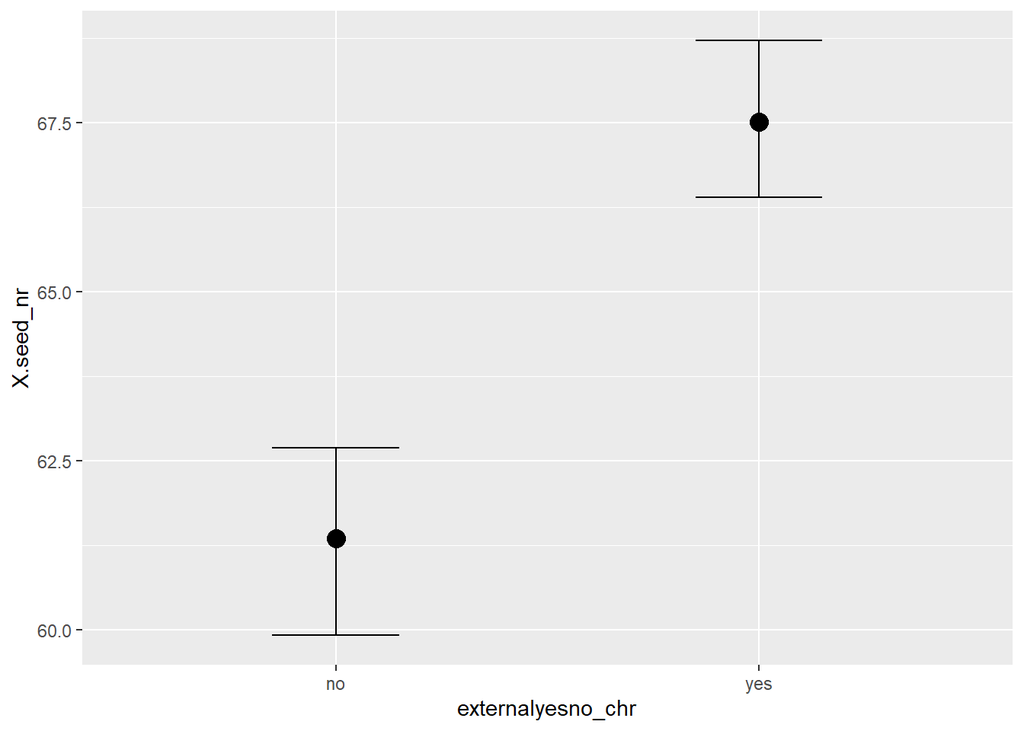

```r
plot(conditional_effects(model1.1, points = TRUE))
```

Additionally we constrain the model to look at only the 1 minute long trials.

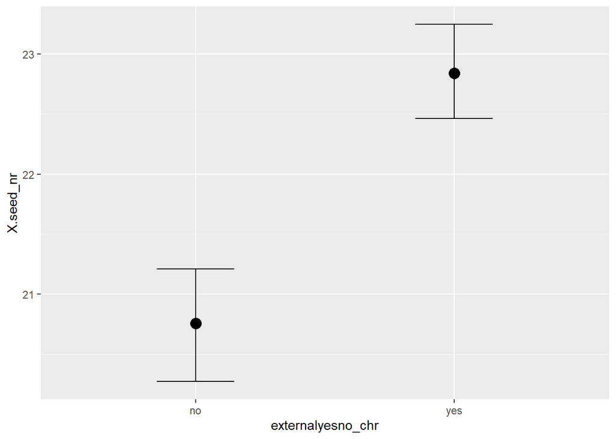

```r
plot(conditional_effects(model1.1, points = TRUE,
                         conditions = data.frame(trial_length = c(60, 60))))
```

### I model the relationship between looking up and the occurance of external events.

### 2. up_nr ~ externalyesno_chr + offset(log(trial_length))

```r
model2.1 <-brm(up_nr ~ externalyesno_chr + offset(log(trial_length)),
               family = poisson,
               data = data,
               chain = 2)
summary(model2.1)
```

```
##  Family: poisson
##   Links: mu = log
## Formula: up_nr ~ externalyesno_chr + offset(log(trial_length))
##    Data: data (Number of observations: 296)
##   Draws: 2 chains, each with iter = 2000; warmup = 1000; thin = 1;
##          total post-warmup draws = 2000
##
## Population-Level Effects:
##                      Estimate Est.Error l-95% CI u-95% CI Rhat Bulk_ESS
## Intercept               -3.08      0.03    -3.15    -3.02 1.00     1646
## externalyesno_chryes     0.06      0.04    -0.02     0.14 1.00     2012
##                      Tail_ESS
## Intercept                1214
## externalyesno_chryes     1451
##
## Draws were sampled using sampling(NUTS). For each parameter, Bulk_ESS
## and Tail_ESS are effective sample size measures, and Rhat is the potential
## scale reduction factor on split chains (at convergence, Rhat = 1).
```

```r
# ?predict.brmsfit
predict(model2.1,
        newdata = data.frame(externalyesno_chr = c("yes", "no"),
                             trial_length = c(60, 60)))
```

```
##      Estimate Est.Error Q2.5 Q97.5
## [1,]   2.9130  1.698492    0     7
## [2,]   2.7855  1.690834    0     7
```

##### The average trial length:

```r
mean(data$trial_length)
```

```
## [1] 177.3414
```

I model the relationship between looking up and the occurance of external events.

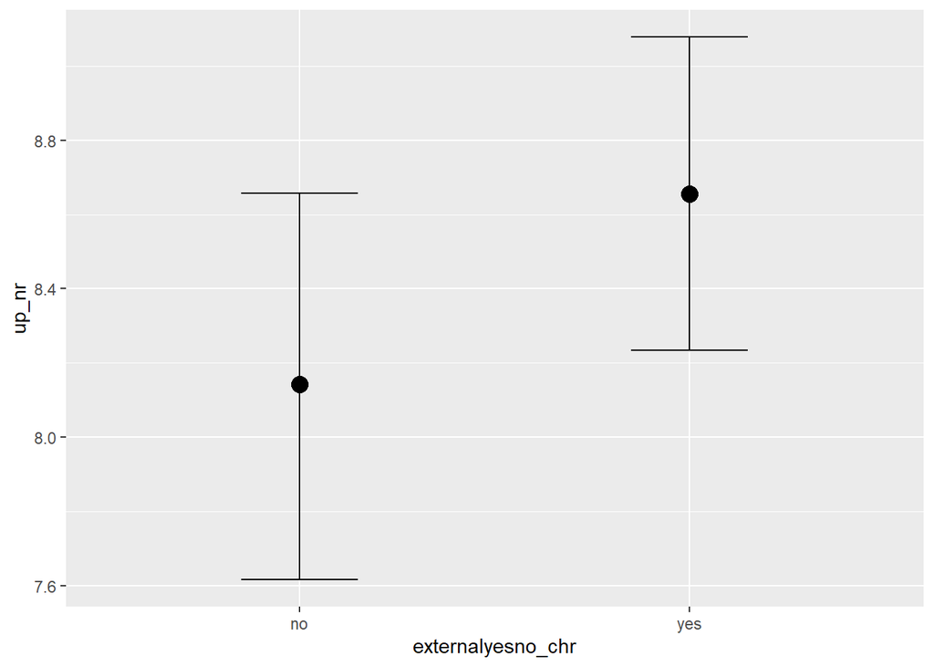

```r
plot(conditional_effects(model2.1, points = TRUE))
```

Additionally we constrain the model to look at only the 1 minute long trials.

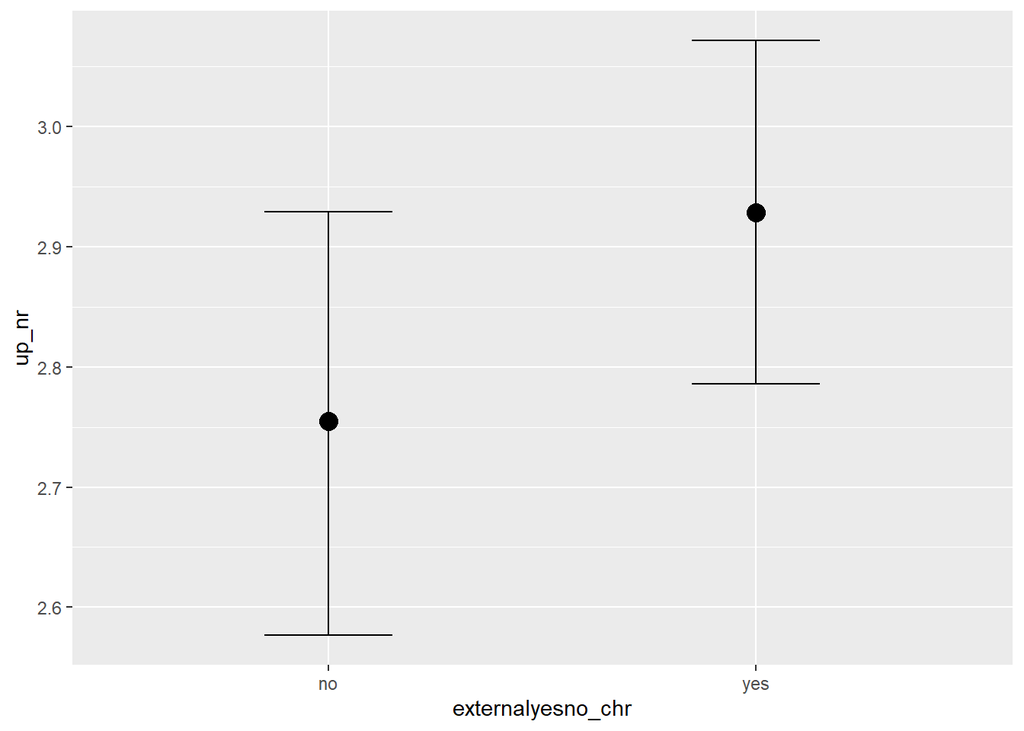

```r
plot(conditional_effects(model2.1, points = TRUE,
                         conditions = data.frame(trial_length = c(60, 60))))
```

3. Relationship between the number of seeds eaten and the number of times the animal looks up, with trial length as an offset parameter. X.seed_nr ~ up_nr_min + offset(log(trial_length))

```r
#data['up_nr_min']<- (data$up_nr/data$trial_length)*60

#data['up_trial'] = (data$up_nr_min)*(data$trial_length/60)
model3.1 <-brm(X.seed_nr ~ up_nr_min + offset(log(trial_length)),
               family = poisson,
               data = data,
               chain = 2)
summary(model3.1)
```

```
##  Family: poisson
##   Links: mu = log
## Formula: X.seed_nr ~ up_nr_min + offset(log(trial_length))
##    Data: data (Number of observations: 296)
##   Draws: 2 chains, each with iter = 2000; warmup = 1000; thin = 1;
##          total post-warmup draws = 2000
##
## Population-Level Effects:
##           Estimate Est.Error l-95% CI u-95% CI Rhat Bulk_ESS Tail_ESS
## Intercept    -1.27      0.01    -1.30    -1.25 1.00     1218     1329
## up_nr_min     0.09      0.00     0.08     0.09 1.00     1759     1295
##
## Draws were sampled using sampling(NUTS). For each parameter, Bulk_ESS
## and Tail_ESS are effective sample size measures, and Rhat is the potential
## scale reduction factor on split chains (at convergence, Rhat = 1).
```

# Number of times the animal looks up is positively related with the number of seeds the animal eats

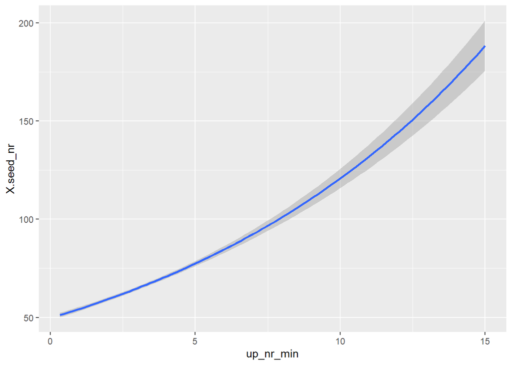

```r
plot(conditional_effects(model3.1, points = TRUE))
```